# Summary:

- Matplotlib `Figure` and `Axes` objects
- How customize the plot using `Axes` functions
- How to integrate Pandas and Matplotlib using the option `ax` for better customization

# Today:

## 1. Combined plots and grouped plot using seaborn

## 2. Introduction to statistical plots

- **Example 1:**
  - Reproduce the plot from previous class
  - Repeat the same process for average weight variable and present the two plots next to each other (*hint:* use `plt.subplots(nrows=1,ncols=2)`)

```python
import matplotlib.pyplot as plt
import pandas as pd

# Define the plot style
plt.style.use('seaborn-darkgrid')
```

```python
# Import and merge data

names = pd.read_csv('../lecture17/data/names.csv')
features = pd.read_csv('../lecture17/data/features.csv')
cars = pd.merge(names, features, on = 'vehicle id')
```

```python
# Create subset of the data and aggregate by model

cars_model = cars[['model', 'mpg', 'cylinders', 'displacement', 'weight', 'acceleration']].groupby('model', as_index = False).mean()
```

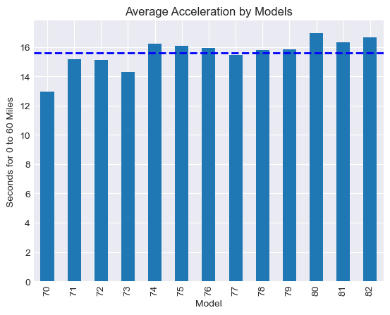

```python
fig1, ax1 = plt.subplots()
cars_model.plot(kind = 'bar', x = 'model', y = 'acceleration', ax=ax1)

ax1.set_xlabel('Model')
ax1.set_ylabel('Seconds for 0 to 60 Miles')
ax1.set_title('Average Acceleration by Models')

ax1.legend().set_visible(False)

mean_acc = cars_model['acceleration'].mean()
ax1.axhline(mean_acc, color='b', linestyle='--', linewidth=2)
```

- How to combine the two plots in one figure using Pandas plots?
- **Example 1... continuation**
  - Both plots share the same x-axis (Model). Rotate the plots and use the same labels to represent the Model axis (*hint:* use the option `sharey=True`)
  - Use the notation set(title, xlabel, ylabel) instead of the previous notation

## 1. Using Seaborn instead of Pandas to create grouped plots

- We can use the package `seaborn` instead of `pandas` to create different plots
- For example, we can use `seaborn` to create barplots. **Advantage:** easy to create grouplots
- **Important:** figure-level vs. axes-level functions in `seaborn` (we can combine axes-level functions with `matplotlib` as with `pandas` **but NOT** figure-level functions)

[figure not shown]

- **Example 2:**
1. Create a new dataframe with the average acceleration group by models and origin
2. Use seaborn to create a barplot with the **axes-level** function `sns.barplot` that separates the acceleration of each model by Origin (*hint:* use the option `hue`)
3. Change the palette to `mako` and the title to 'Acceleration by Model and Origin'
4. Use seaborn to create a [lineplot](https://seaborn.pydata.org/generated/seaborn.lineplot.html) to track average acceleration and weight/100 by model
5. Change the palette to `mako` and the title to 'Acceleration and Weight by Model'